# Chapter 3 Make a Plot

```r
 knitr::opts_chunk$set(fig.width = 12, fig.height = 9)
```

```r
library(dplyr)
library(socviz)
library(gapminder)
library(tibble)
library(readr)
library(ggplot2)
library(scales)
```

## 3.1 How Ggplot Works

## 3.2 Tidy Data

[figure not shown]

```r
?mgcv::`mgcv-package`
ggplot(gapminder, aes(gdpPercap, lifeExp)) +
  geom_point() +
  geom_smooth(method = mgcv::gam)
```

‘gam’ means that it has fit a generalized additive model. geom_smooth is a function with other arguments. Try setting its method argument to ‘lm’ for linear model (note: ‘lm’ is a function as well):

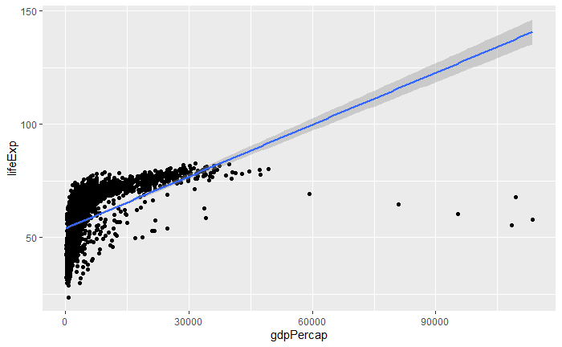

```r
?geom_smooth
?lm
ggplot(gapminder, aes(gdpPercap, lifeExp)) +
  geom_point() +
  geom_smooth(method = lm)
```

Data bunched up on left side. x scale would look better if we used a log scale and the mgcv::gam smoothing method. Note the points are repositioned to a more linear trend shape because of the rescaling.

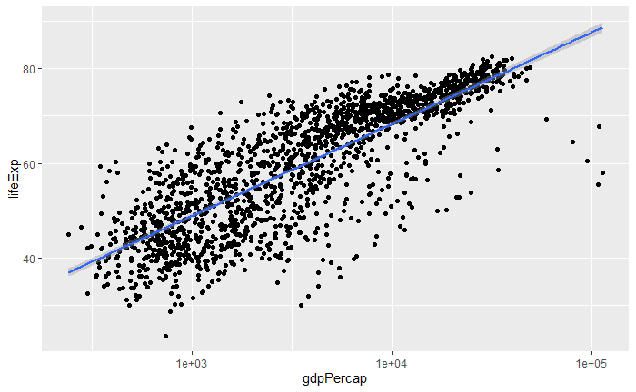

```r
ggplot(gapminder, aes(gdpPercap, lifeExp)) +
  geom_point() +
  geom_smooth(method = mgcv::gam) +
  scale_x_log10()
```

Decorating the plot: put dollar signs on x axis using ‘scales’ package. The ‘labels’ argument modifies the axis text.

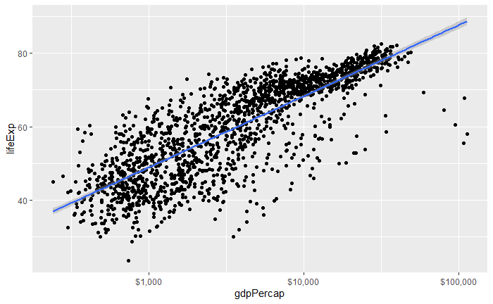

```r
ggplot(gapminder, aes(gdpPercap, lifeExp)) +
  geom_point() +
  geom_smooth(method = mgcv::gam) +
  scale_x_log10(labels = scales::dollar)
```

## 3.5 Mapping aesthetics vs setting them

The aes property ‘color’ will represent the variable ‘continent’:

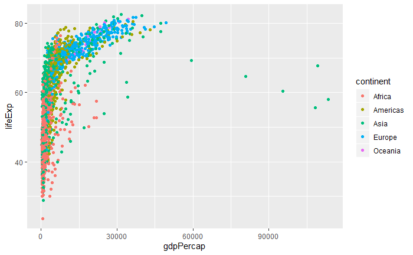

```r
ggplot(gapminder, aes(gdpPercap, lifeExp, color = continent)) +
  geom_point()
```

aes is for linking a variable to ‘color’, ‘size’, etc. To actually change point colors, define it in a geom_. See the below help for list of aesthetics that geom_point understands

```r
?geom_point
```

Additional decorations with ‘alpha’ and ‘labs()’:

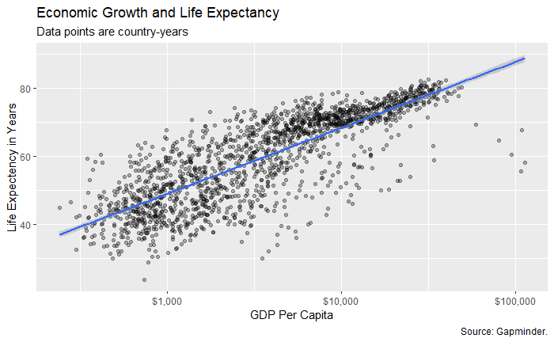

```r
ggplot(gapminder, aes(gdpPercap, lifeExp)) +
  geom_point(alpha = 0.3) +
  geom_smooth(method = mgcv::gam) +
  scale_x_log10(labels = scales::dollar) +
  labs(
    x = "GDP Per Capita",
    y = "Life Expectency in Years",
    title = "Economic Growth and Life Expectancy",
    subtitle = "Data points are country-years",
    caption = "Source: Gapminder."
  )
```

All geom’s inherit from the original aes settings (note: using ‘fill’ for the error bars):

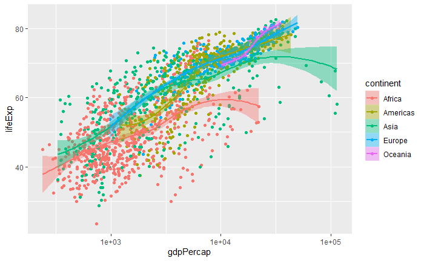

```r
ggplot(gapminder, aes(gdpPercap, lifeExp, color = continent, fill = continent)) +
  geom_point() +
  geom_smooth(method = stats::loess) +
  scale_x_log10()
```

## 3.6 Aesthetics can be mapped per geom_

By default geom_’s inherit their mappings from the ggplot() function. We can change this by specifying different aethetics for each geom_. We use same aes() expression in the ggplot() call but now use it in the geom_ function as well, specifying the aes() we want for each one. Example–set the aes() of geom_point to ’aes(color = log(pop)): Note the use of ’theme() function for controlling the legend position.

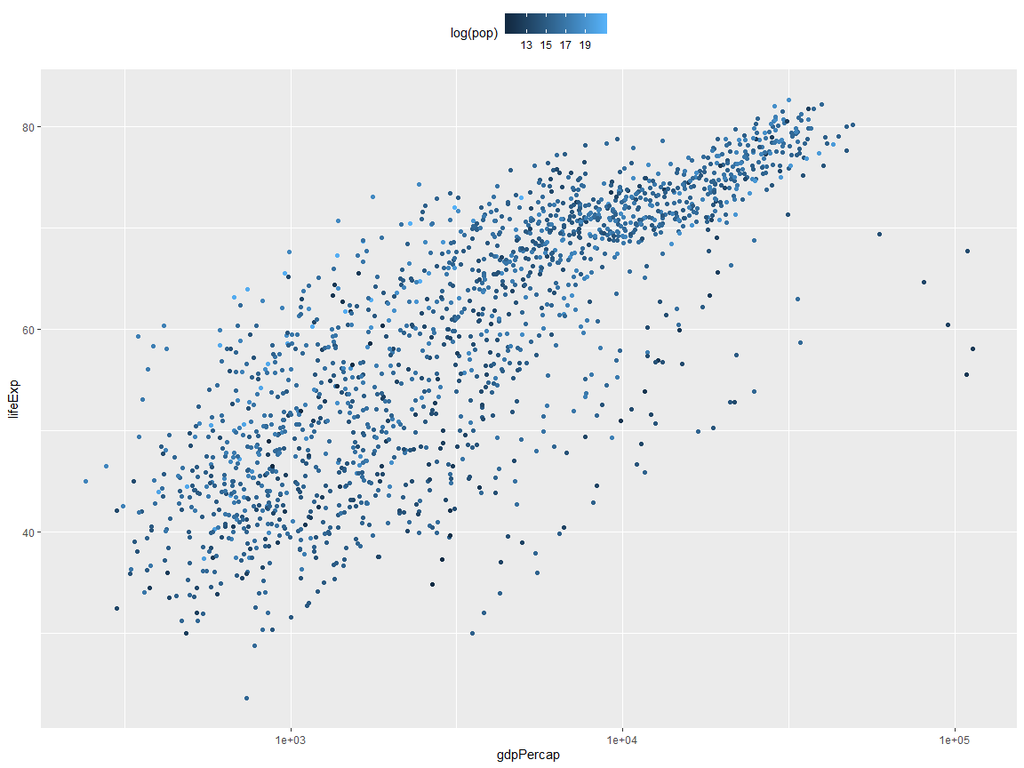

```r
?ggplot2::theme
ggplot(gapminder, aes(gdpPercap, lifeExp)) +
  geom_point(aes(color = log(pop))) +
  scale_x_log10() +
  theme(legend.position = "top")
```

## 3.7 Save your work

```r
ggsave(filename = "figures/gdpPercap_lifeExp_log.jpg", height = 4, width = 6, units = "in")
ggsave(filename = "figures/gdpPercap_lifeExp_log.svg")
```

## 3.8 Where to go next